# HW_02

Kendall Loh

10/1/2018

# Homework 02 - Data Wrangling

## Kendall Loh

### Selection of Data and Tidying

#### 1. Remove all columns you do not need for the analysis.

#### 2. Select the following variables and remove all others: Binge Drinking (Overall, Male, Female), and Poverty (Overall)

#### 3. Convert the dataset to a tidy data set using the commands from the tidyr package

#### 4. Rename the variables to follow the format below. `state`, `stateabb`, `year`, `binge_all`, `binge_male`, `binge_female`, `poverty`]. Save the cleaned dataset as binge_clean.csv.

### Data Transformation and Summary Results

#### 5. Produce a table that shows the `overall`, `female` and `male` binge drinking prevalences across U.S. states in the most recent year of data for the Top 10 binge drinking states. (i.e., the ones with the highest prevalence in the overall population).

```r
print(Top_10_Drinking_Table)
```

```
##
##
## state                  stateabb    year   binge_all   binge_female   binge_male
## ---------------------  ---------  -----  ----------  -------------  -----------
## District of Columbia   DC          2016        25.6           21.3         30.5
## North Dakota           ND          2016        24.8           17.2         32.1
## Wisconsin              WI          2016        24.6           19.5         29.7
## Minnesota              MN          2016        21.3           16.2         26.5
## Iowa                   IA          2016        21.2           15.4         27.1
## Guam                   GU          2016        20.7           11.2         29.8
## Nebraska               NE          2016        20.0           13.1         27.2
## Illinois               IL          2016        19.9           14.5         25.6
## Pennsylvania           PA          2016        19.4           13.8         25.3
## Montana                MT          2016        18.9           13.0         24.9
```

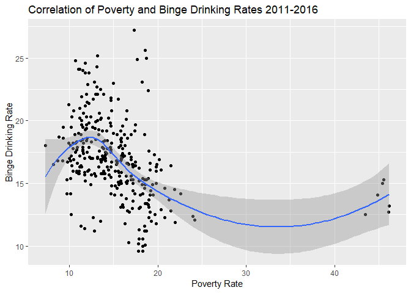

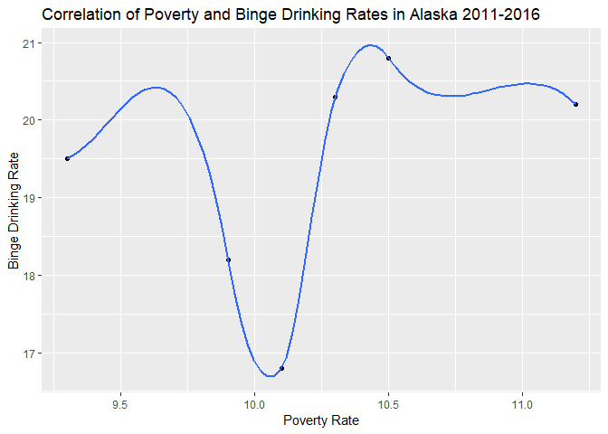

#### 7. Calculate the average annual growth rates (in percent) of `overall` binge drinking across states for the years the data is available.

##### Suggestion: group the data by state, and use the `first()` and `last()` commands in the `summarize` command followed by dividing the calculated percentage increase by the number of years. provide a table of the **5 states with the largest increases** and the **5 states with the largest decreases** in `overall` binge drinking prevalence over the time period.

```r
k_large_inc
```

| state | ave_growth |
| --- | --- |
| Tennessee | 0.5166667 |
| Guam | 0.4000000 |
| South Carolina | 0.2333333 |
| West Virginia | 0.2000000 |
| Pennsylvania | 0.1833333 |

```r
k_small_inc
```

| state | ave_growth |
| --- | --- |
| Oklahoma | -0.7833333 |
| Rhode Island | -0.6333333 |
| Delaware | -0.5500000 |
| Georgia | -0.5500000 |
| Illinois | -0.5166667 |